# ЕГЭ 2018 Вариант 17 EGE 2018 Variant 17

Использованы материалы:

The list of used links and books:

[ЕГЭ 2018. Математика. Профильный уровень. 20 вариантов тестов. Тематическая рабочая тетрадь.](https://drive.google.com/file/d/0B8CJrELbJAyodmtvbV8xcEtZXzA/view)

[SymPy Tutorials](http://nbviewer.jupyter.org/url/www.inp.nsk.su/~grozin/python/sympy.ipynb)

[LaTeX Mathematics](https://en.wikibooks.org/wiki/LaTeX/Mathematics)

[Метод рационализации неравенств (логарифмы)](http://internat.msu.ru/wp-content/uploads/2015/11/Metod-ratsionalizatsii-neravenstv-1.pdf)

```python
%%html
<style>
@import url('https://fonts.googleapis.com/css?family=Roboto&effect=3d|scuffed-steel|static|canvas-print|');
a, h1 h2, h3, h4, div.text_cell_render {font-family: 'Roboto'; text-shadow: 4px 4px 4px #aaa;}

h2, h3, div.output_prompt, div.output_area pre {color: slategray;}
h1, h4, div.input_prompt {color: steelblue;}
a, div.output_subarea {color: darkblue;}

span {text-shadow: 4px 4px 4px #aaa;}

body, div.output_stderr pre{background-color: aliceblue;}
div.output_stderr {background-color: slategray;}
</style>
```

```python
import numpy
import pandas
import math

import matplotlib.pyplot as plt
import matplotlib.patches as pat
from mpl_toolkits.mplot3d import Axes3D
from mpl_toolkits.mplot3d.art3d import Poly3DCollection, Line3DCollection

from __future__ import unicode_literals

import matplotlib
%matplotlib inline
```

```python
import sympy
from sympy import *
from sympy import init_printing
init_printing()
```

```python
answer_dictionary = dict()
```

## Часть 1 Part 1

[figure not shown]

### Задание 1 / Task 1

Установка двух счётчиков воды (холодной и горячей) стоит 2400 руб.

До установки счётчиков Александр платил за водоснабжение ежемесячно 1500 руб.

После установки счётчиков оказалось, что в среднем за месяц он расходует воды на 800 руб.

За сколько месяцев установка счётчиков окупится?

Installation of two water registers (cold and hot) costs 2400 rubles.

Prior to the installation of registers, Alexander paid for water supply monthly 1500 rubles.

After installing the registers it turned out that on average for a month, he wastes 800 rubles.

For how many months the installation of registers will pay off?

Ежемесячная плата снизилась на $1500 - 800 = 700$ рублей.

Установка окупится через $2400 / 700 \approx 4$ месяца.

Округление производится до целого в большую сторону.

The monthly fee decreased by $1500 - 800 = 700$ rubles.

The installation will pay off after $2400 / 700 \approx 4$ months.

The rounding is performed up to the integer in the larger side.

### Ответ / Answer: 4

```python
answer_dictionary[1] = str(math.ceil(2400 / (1500 - 800)))
```

[figure not shown]

### Задание 2 / Task 2

На диаграмме показано число запросов со словом `ФУТБОЛ`, сделанных на некотором поисковом сайте во все месяцы с января по сентябрь 2010 года.

По горизонтали указываются месяцы, по вертикали - число запросов за данный месяц.

Определите по диаграмме наименьшее месячное число запросов со словом `ФУТБОЛ` в указанный период.

The diagram shows the number of queries with the word `FOOTBALL` made on some search site in all months from January to September 2010.

Months are indicated in the horizontal line, in the vertical line - the number of requests for a given month.

Determine the smallest number of queries with the word `FOOTBALL` in the specified period from the diagram.

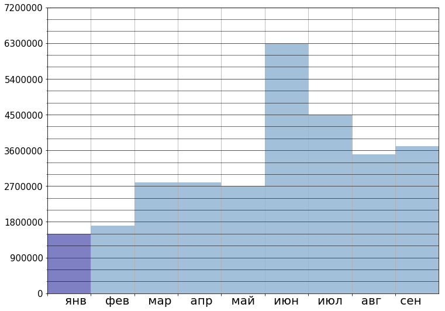

```python
months = ['янв','фев','мар','апр','май','июн','июл','авг','сен']
df=pandas.DataFrame({'months': months,
                     'queries': [15,17,28,28,27,63,45,35,37]})
fig,ax = plt.subplots()
df.plot(kind='bar', x='months', ax=ax,
        figsize=(12,9), grid=True,
        color='steelblue', alpha=0.5, align='edge', width=1)

ax.patches[0].set_facecolor('darkblue')

plt.xticks(visible=False)
plt.xlabel('     '.join(months), fontsize=20)

ax.set_yticks(numpy.arange(0, 81, 9))
ax.set_yticklabels(['0','900000','1800000','2700000','3600000',
                    '4500000','5400000','6300000','7200000'], fontsize=15)
ax.set_yticks(numpy.arange(0, 81, 3), minor=True)
ax.grid(which='minor', alpha=0.7, color='black')

ax.legend().set_visible(False)

plt.xlim(0,9)
plt.ylim(0,72);
```